# Inteligencia Artificial I: TP7 - Machine Learning - Parte A

Importar las librerías necesarias:

```r
library(dplyr)
library(readr)
library(caret)
library(rpart)
library(ggplot2)
```

Seleccionar de manera uniformemente aleatoria el 20% del conjunto de datos y crear un nuevo archivo con el nombre de *arbolado-publico-mendoza-2021-validation.csv* y el 80% restante con el nombre de *arbolado-publico-mendoza-2021-train.csv*:

```r
trees_dataset <- read_csv("data/arbolado-mza-dataset.csv")
# Get a sample of random indices for the train dataset.
x <- seq(1:nrow(trees_dataset))
size <- (nrow(trees_dataset) * 80) /100
train_idx<-sample(x,size)

# Split dataset.
trees_train <- trees_dataset[train_idx,]
trees_test <- trees_dataset[-train_idx,]

trees_dataset %>% nrow() # Original dataset size
```

```
[1] 31912
```

```r
trees_train %>% nrow() # Train dataset size
```

```
[1] 25529
```

```r
trees_test %>% nrow()  # Test dataset size
```

```
[1] 6383
```

```r
#write.csv(trees_train, 'data/arbolado-publico-mendoza-2021-train.csv')
#write.csv(trees_test, 'data/arbolado-publico-mendoza-2021-validation.csv')
```

A partir del archivo arbolado-publico-mendoza-2021-train.csv, responder las siguientes preguntas: ¿Cuál es la distribución de la clase inclinacion_peligrosa?

```r
distribution <- trees_train %>% group_by(inclinacion_peligrosa) %>% summarise(total=n())

# Distribution of dangerous trees:
distribution
```

| inclinacion_peligrosa | total |
| --- | --- |
| 0 | 22650 |
| 1 | 2879 |

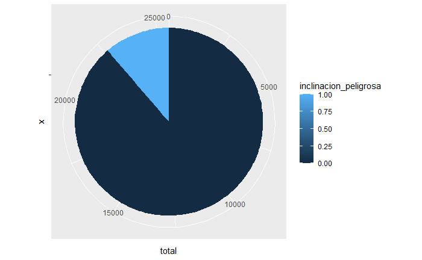

```r
ggplot(distribution, aes(x = "", y = total, fill = inclinacion_peligrosa)) +
  geom_col() +
  coord_polar(theta = "y")
```

¿Se puede considerar alguna sección más peligrosa que otra?

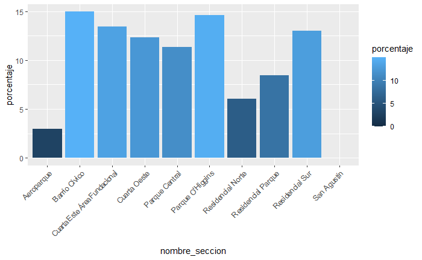

```r
distribution_zones_danger <- trees_train %>% group_by(nombre_seccion) %>% summarise(porcentaje=round(sum(inclinacion_peligrosa)/n()*100, digits = 2))

# Percentage of dangerous trees per zone:
ggplot(distribution_zones_danger, aes(nombre_seccion, porcentaje, fill = porcentaje)) + geom_bar(stat="identity") + theme(axis.text.x = element_text(angle = 45, hjust = 1))
```

¿Se puede considerar alguna especie más peligrosa que otra?

```r
distribution_species_danger <- trees_train %>% group_by(especie) %>% summarise(peligrosos = sum(inclinacion_peligrosa), total = n(), porcentaje=round(sum(inclinacion_peligrosa)/n()*100, digits = 2))

distribution_species_danger
```

| especie | peligrosos | total | porcentaje |
| --- | --- | --- | --- |
| Acacia SP | 90 | 563 | 15.99 |
| Acacia visco | 5 | 74 | 6.76 |
| Acer | 10 | 550 | 1.82 |
| Aguaribay | 22 | 232 | 9.48 |
| Ailanthus | 4 | 165 | 2.42 |
| Algarrobo | 2 | 4 | 50.00 |
| Arabia | 0 | 3 | 0.00 |
| Braquiquito | 0 | 61 | 0.00 |
| Caducifolio | 18 | 358 | 5.03 |
| Catalpa | 5 | 27 | 18.52 |

[output cut: 22 more lines]

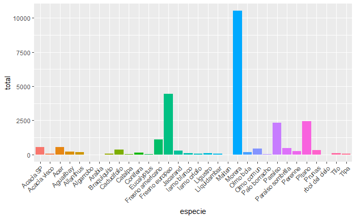

```r
#Distribution of species:
ggplot(distribution_species_danger, aes(especie, total, fill = especie)) + geom_bar(stat="identity") + theme(legend.position = "none", axis.text.x = element_text(angle = 45, hjust = 1))
```

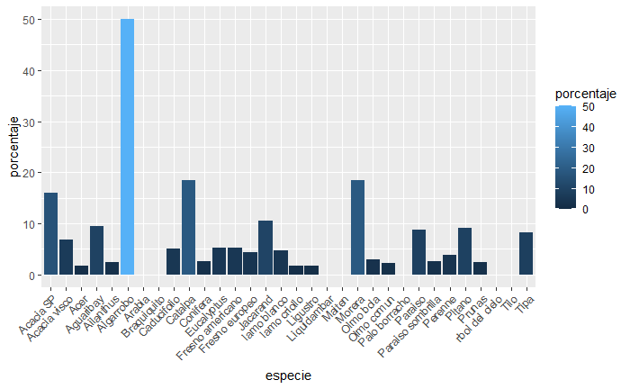

```r
#Percentage of dangerous trees per specie:
ggplot(distribution_species_danger, aes(especie, porcentaje, fill = porcentaje)) + geom_bar(stat="identity") + theme(axis.text.x = element_text(angle = 45, hjust = 1))
```

A partir del archivo *arbolado-publico-mendoza-2021-train.csv*: Generar un histograma de frecuencia para la variable *circ_tronco_cm*.

```r
trees_train <- read_csv("data/arbolado-publico-mendoza-2021-train.csv")
```

```
* `` -> ...1
```

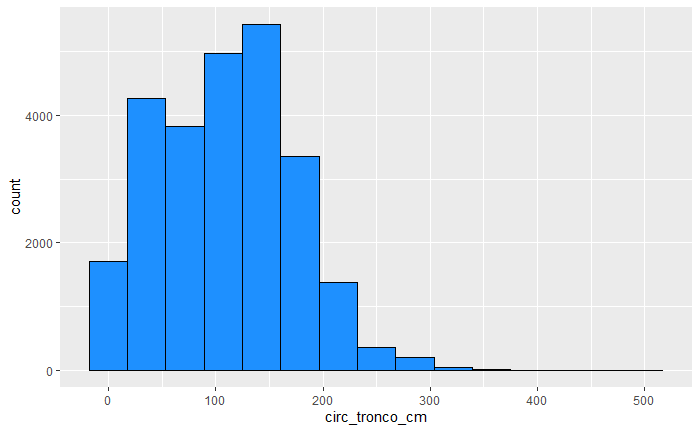

```r
# Histogram of tree trunk diameter distribution:
ggplot(data = trees_train, aes(x = circ_tronco_cm)) + geom_histogram(bins=15, color="black", fill="dodgerblue") + theme(legend.position = "none")
```

Repetir el punto b) pero separando por la clase de la variable inclinación_peligrosa.

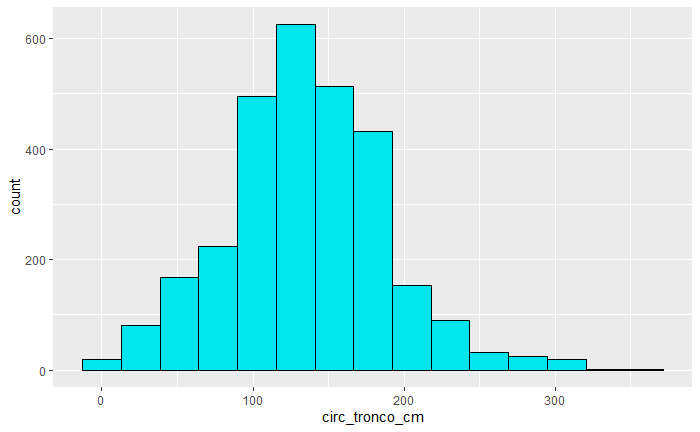

```r
trees_train_dangerous = trees_train %>% filter(inclinacion_peligrosa == 1)

# Histogram of dangerous trees' trunk diameter distribution:
ggplot(data = trees_train_dangerous, aes(x = circ_tronco_cm)) + geom_histogram(bins=15, color="black", fill="turquoise2") + theme(legend.position = "none")
```

Crear una nueva variable categórica de nombre circ_tronco_cm_cat a partir circ_tronco_cm, en donde puedan asignarse solo 4 posibles valores [ muy alto, alto, medio, bajo ]. Utilizar la información del punto a. para seleccionar los puntos de corte para cada categoría. Guardar el nuevo dataframe bajo el nombre de *arbolado-publico-mendoza-2021-circ_tronco_cm-train.csv*

```r
# Add and fill the new column.
trees_with_cm_cat <- trees_train %>% mutate(circ_tronco_cm_cat = ifelse(circ_tronco_cm <= 100,'bajo',
                                                                ifelse(circ_tronco_cm <= 200, 'medio',
                                                                       ifelse(circ_tronco_cm <= 300, 'alto',
                                                                              'muy alto'))))

trees_with_cm_cat
```

| ...1 | id | especie | ultima_modificacion | altura | circ_tronco_cm | diametro_tronco | long | lat | seccion | nombre_seccion | area_seccion | inclinacion_peligrosa | circ_tronco_cm_cat |
| --- | --- | --- | --- | --- | --- | --- | --- | --- | --- | --- | --- | --- | --- |
| 1 | 11621 | Morera | 27/01/2011 14:07 | Alto (> 8 mts) | 80.0 | Grande | -68.84968 | -32.86642 | 6 | Residencial Norte | 2694682 | 0 | bajo |
| 2 | 954 | Prunas | 10/01/2012 18:04 | Muy bajo (1 - 2 mts) | 4.0 | Chico | -68.84801 | -32.87274 | 6 | Residencial Norte | 2694682 | 0 | bajo |
| 3 | 40726 | Morera | 18/04/2011 09:15 | Alto (> 8 mts) | 100.0 | Grande | -68.84319 | -32.88513 | 1 | Parque Central | 1655358 | 1 | bajo |
| 4 | 20254 | Fresno europeo | 17/05/2011 10:31 | Medio (4 - 8 mts) | 78.0 | Grande | -68.86019 | -32.89261 | 5 | Residencial Sur | 2423809 | 0 | bajo |
| 5 | 21539 | Morera | 08/06/2011 11:35 | Alto (> 8 mts) | 105.0 | Grande | -68.85380 | -32.89498 | 5 | Residencial Sur | 2423809 | 1 | medio |
| 6 | 47323 | Morera | 21/09/2011 11:38 | Alto (> 8 mts) | 192.0 | Grande | -68.83072 | -32.87457 | 4 | Cuarta Este rea Fundacional | 1822016 | 0 | medio |
| 7 | 44251 | Morera | 13/10/2011 11:16 | Alto (> 8 mts) | 240.0 | Grande | -68.83407 | -32.88434 | 3 | Parque O'Higgins | 1531146 | 0 | alto |
| 8 | 36716 | Morera | 14/06/2011 10:31 | Medio (4 - 8 mts) | 110.0 | Grande | -68.86016 | -32.88166 | 7 | Residencial Parque | 1786336 | 0 | medio |
| 9 | 6957 | Fresno europeo | 06/06/2011 10:52 | Alto (> 8 mts) | 128.0 | Grande | -68.85936 | -32.89635 | 5 | Residencial Sur | 2423809 | 0 | medio |
| 10 | 4720 | Acer | 27/07/2011 09:57 | Muy bajo (1 - 2 mts) | 20.0 | Chico | -68.84086 | -32.86542 | 4 | Cuarta Oeste | 1173333 | 0 | bajo |

[output cut: 990 more lines]

```r
#write.csv(trees_with_cm_cat, 'data/arbolado-publico-mendoza-2021-circ_tronco_cm-train.csv')
```

Clasificador aleatorio: Implementar una función que dado un conjunto de observaciones (data.frame) genere una nueva columna de nombre prediction_prob con un valor aleatorio entre 0 y 1.

```r
add_prediction_prob_col <- function(df) {
  rows <- nrow(df)

  # Assigns a different random number to each row.
  df$prediction_prob <- runif(rows, 0, 1)
  return(df)
}
```

Implementar una función de nombre random_classifier, que reciba como parámetro el dataframe generado con anterioridad y a partir de la columna predictions_prob genere una nueva columna prediction_class bajo el siguiente criterio:

`if prediction_prob > 0.5 then prediction_class=1 else prediction_class=0`

La función deberá devolver el dataframe original junto a la nueva columna generada.

```r
random_classifier <- function(df) {
  # Assign a class to each element based on the random prediction for that element.
  df <- df %>% mutate(prediction_class = ifelse(prediction_prob > 0.5, 1 ,0))
  return(df)
}
```

Cargar el archivo *arbolado-publico-mendoza-2021-validation.csv* como un data.frame y aplicarle la función random_classifier.

```r
trees_test <- read_csv("data/arbolado-publico-mendoza-2021-validation.csv")
```

```
* `` -> ...1
```

```r
# Add the prediction_prob column first, then call random_classifier with the generated dataframe.
trees_test_randomly_classified <- random_classifier(add_prediction_prob_col(trees_test))

trees_test_randomly_classified
```

| ...1 | id | especie | ultima_modificacion | altura | circ_tronco_cm | diametro_tronco | long | lat | seccion | nombre_seccion | area_seccion | inclinacion_peligrosa | prediction_prob | prediction_class |
| --- | --- | --- | --- | --- | --- | --- | --- | --- | --- | --- | --- | --- | --- | --- |
| 1 | 7 | Morera | 02/03/2012 13:19 | Medio (4 - 8 mts) | 110 | Grande | -68.85730 | -32.89583 | 5 | Residencial Sur | 2423809 | 0 | 0.2874138667 | 0 |
| 2 | 15 | Morera | 02/03/2012 13:04 | Bajo (2 - 4 mts) | 56 | Mediano | -68.85676 | -32.89588 | 5 | Residencial Sur | 2423809 | 1 | 0.0144238945 | 0 |
| 3 | 19 | Fresno americano | 02/03/2012 12:56 | Bajo (2 - 4 mts) | 34 | Mediano | -68.85654 | -32.89590 | 5 | Residencial Sur | 2423809 | 0 | 0.6264520334 | 1 |
| 4 | 24 | Fresno europeo | 02/03/2012 12:51 | Bajo (2 - 4 mts) | 44 | Mediano | -68.85608 | -32.89594 | 5 | Residencial Sur | 2423809 | 0 | 0.5136765053 | 1 |
| 5 | 40 | Fresno europeo | 01/03/2012 12:46 | Medio (4 - 8 mts) | 140 | Grande | -68.85553 | -32.89653 | 5 | Residencial Sur | 2423809 | 0 | 0.3283617664 | 0 |
| 6 | 43 | Olmo bola | 01/03/2012 12:42 | Medio (4 - 8 mts) | 160 | Grande | -68.85555 | -32.89672 | 5 | Residencial Sur | 2423809 | 0 | 0.0760858108 | 0 |
| 7 | 46 | Fresno europeo | 01/03/2012 12:38 | Bajo (2 - 4 mts) | 16 | Chico | -68.85561 | -32.89689 | 5 | Residencial Sur | 2423809 | 0 | 0.2994483251 | 0 |
| 8 | 59 | Morera | 05/03/2012 10:55 | Medio (4 - 8 mts) | 110 | Grande | -68.85669 | -32.89676 | 5 | Residencial Sur | 2423809 | 0 | 0.4179035027 | 0 |
| 9 | 63 | Fresno europeo | 05/03/2012 10:40 | Bajo (2 - 4 mts) | 22 | Mediano | -68.85666 | -32.89655 | 5 | Residencial Sur | 2423809 | 0 | 0.2670510812 | 0 |
| 10 | 65 | Fresno europeo | 05/03/2012 10:38 | Bajo (2 - 4 mts) | 60 | Mediano | -68.85667 | -32.89645 | 5 | Residencial Sur | 2423809 | 0 | 0.8297673464 | 1 |

[output cut: 990 more lines]

```r
NA
```

A partir de la columna recientemente generada y la columna actual calcular utilizando lenguaje R (dplyr): - Número de árboles CON inclinación peligrosa que fueron correctamente predecidos como peligrosos por el modelo/algoritmo. (True Positive) - Número de árboles SIN inclinación peligrosa que fueron correctamente predecidos como no peligrosos por el modelo. (True Negative) - Número de árboles SIN inclinación peligrosa que fueron incorrectamente predecidos como peligrosos según el modelo. (False Positives) - Número de árboles CON inclinación peligrosa que fueron incorrectamente predecidos como no peligrosos según el modelo. (False Negatives)

```r
confusion_matrix <- function(df) {
  # Calculate all values.
  true_positives <- df %>% filter(inclinacion_peligrosa == 1 & prediction_class == 1) %>% nrow()
  true_negatives <- df %>% filter(inclinacion_peligrosa == 0 & prediction_class == 0) %>% nrow()
  false_positives <- df %>% filter(inclinacion_peligrosa == 0 & prediction_class == 1) %>% nrow()
  false_negatives <- df %>% filter(inclinacion_peligrosa == 1 & prediction_class == 0) %>% nrow()

  # Format and return values in a dataframe.
  confusion_matrix <- data.frame('n'= c("Actual YES", "Actual NO"),
                                 "Predicted YES" = c(true_positives, false_positives),
                                 "Predicted NO"= c(false_negatives, true_negatives))
  return(confusion_matrix)
}

confusion_matrix(trees_test_randomly_classified)
```

| n | Predicted.YES | Predicted.NO |
| --- | --- | --- |
| Actual YES | 330 | 373 |
| Actual NO | 2857 | 2823 |

Clasificador por clase mayoritaria: Implementar una función de nombre biggerclass_classifier, que reciba como parámetro el dataframe generado con anterioridad nueva columna prediction_class en donde se asigne siempre de la clase mayoritaria. La función deberá devolver el dataframe original junto a la nueva columna generada.

```r
biggerclass_classifier <- function(df) {
  # Obtain the classes distribution.
  classes <- df %>% group_by(inclinacion_peligrosa) %>% summarise(cantidad=n())

  # Get the bigger class and assign that class to all elements.
  bigger_class <- classes[order(-classes$cantidad), ]$inclinacion_peligrosa[1]
  df$prediction_class <- bigger_class
  return(df)
}
```

Repetir los puntos 4.c y 4.d pero aplicando la nueva función biggerclass_classifier.

```r
trees_test <- read_csv("data/arbolado-publico-mendoza-2021-validation.csv")
```

```
* `` -> ...1
```

```r
trees_test_biggerclass_classified <- biggerclass_classifier(trees_test)

trees_test_biggerclass_classified
```

| ...1 | id | especie | ultima_modificacion | altura | circ_tronco_cm | diametro_tronco | long | lat | seccion | nombre_seccion | area_seccion | inclinacion_peligrosa | prediction_class |
| --- | --- | --- | --- | --- | --- | --- | --- | --- | --- | --- | --- | --- | --- |
| 1 | 7 | Morera | 02/03/2012 13:19 | Medio (4 - 8 mts) | 110 | Grande | -68.85730 | -32.89583 | 5 | Residencial Sur | 2423809 | 0 | 0 |
| 2 | 15 | Morera | 02/03/2012 13:04 | Bajo (2 - 4 mts) | 56 | Mediano | -68.85676 | -32.89588 | 5 | Residencial Sur | 2423809 | 1 | 0 |
| 3 | 19 | Fresno americano | 02/03/2012 12:56 | Bajo (2 - 4 mts) | 34 | Mediano | -68.85654 | -32.89590 | 5 | Residencial Sur | 2423809 | 0 | 0 |
| 4 | 24 | Fresno europeo | 02/03/2012 12:51 | Bajo (2 - 4 mts) | 44 | Mediano | -68.85608 | -32.89594 | 5 | Residencial Sur | 2423809 | 0 | 0 |
| 5 | 40 | Fresno europeo | 01/03/2012 12:46 | Medio (4 - 8 mts) | 140 | Grande | -68.85553 | -32.89653 | 5 | Residencial Sur | 2423809 | 0 | 0 |
| 6 | 43 | Olmo bola | 01/03/2012 12:42 | Medio (4 - 8 mts) | 160 | Grande | -68.85555 | -32.89672 | 5 | Residencial Sur | 2423809 | 0 | 0 |
| 7 | 46 | Fresno europeo | 01/03/2012 12:38 | Bajo (2 - 4 mts) | 16 | Chico | -68.85561 | -32.89689 | 5 | Residencial Sur | 2423809 | 0 | 0 |
| 8 | 59 | Morera | 05/03/2012 10:55 | Medio (4 - 8 mts) | 110 | Grande | -68.85669 | -32.89676 | 5 | Residencial Sur | 2423809 | 0 | 0 |
| 9 | 63 | Fresno europeo | 05/03/2012 10:40 | Bajo (2 - 4 mts) | 22 | Mediano | -68.85666 | -32.89655 | 5 | Residencial Sur | 2423809 | 0 | 0 |
| 10 | 65 | Fresno europeo | 05/03/2012 10:38 | Bajo (2 - 4 mts) | 60 | Mediano | -68.85667 | -32.89645 | 5 | Residencial Sur | 2423809 | 0 | 0 |

[output cut: 990 more lines]

```r
confusion_matrix(trees_test_biggerclass_classified)
```

| n | Predicted.YES | Predicted.NO |
| --- | --- | --- |
| Actual YES | 0 | 703 |
| Actual NO | 0 | 5680 |

```r
NA
```

A partir de una matriz de confusión es posible calcular distintas métricas que nos permiten determinar la calidad del modelo de clasificación. Calcular: Accuracy, Precision, Sensitivity, Specificity y calcularlas para las matrices de confusión generadas en los puntos 4 y 5.

```r
# Receives a df created with the confusion_matrix function defined above.
metrics <- function(confusion_matrix) {
  # Get variables values
  TP <- confusion_matrix$Predicted.YES[1]
  TN <- confusion_matrix$Predicted.NO[2]
  FP <- confusion_matrix$Predicted.YES[2]
  FN <- confusion_matrix$Predicted.NO[1]

  # Calculate metrics.
  size <- TP + TN + FP + FN
  accuracy <- (TP+TN) / size
  sensitivity <- TP / (TP+FN)
  specificity <- TN / (TN+FP)
  precision <- TP / (TP+FP)
  negative_predictive_value <- TN / (TN+FN)

  # Return metrics formatted in a dataframe.
  metrics_df <- data.frame("n" = size, "Accuracy" = accuracy, "Precision" = precision, "Sensitivity" = sensitivity, "Specificity" = specificity, "Negative_predictive_value" = negative_predictive_value)

  return(metrics_df)
}

# Metrics for random classifier
metrics(confusion_matrix(trees_test_randomly_classified))
```

| n | Accuracy | Precision | Sensitivity | Specificity | Negative_predictive_value |
| --- | --- | --- | --- | --- | --- |
| 6383 | 0.4939684 | 0.1035457 | 0.4694168 | 0.497007 | 0.8832916 |

```r
# Metrics for bigger-class classifier
metrics(confusion_matrix(trees_test_biggerclass_classified))
```

| n | Accuracy | Precision | Sensitivity | Specificity | Negative_predictive_value |
| --- | --- | --- | --- | --- | --- |
| 6383 | 0.8898637 | NaN | 0 | 1 | 0.8898637 |

Validación cruzada/Cross validation:

La validación cruzada es una técnica para estimar el error de generalización de un algoritmo/modelo de machine learning. La técnica consiste en (previo realizar una mezcla aleatoria) separar el conjunto de datos en k partes (normalmente denominadas folds). Luego en la primera iteración se utilizan k-1 partes para entrenar E1 y se utiliza la restante para test. El proceso se repite por k iteraciones utilizando en cada una diferentes conjuntos de entrenamiento y test.

Crear una función de nombre create_folds() que reciba como parámetro un dataframe y la cantidad de folds y devuelva una lista de R con la siguiente estructura:

`list(Fold1=c(...), Fold2=c(..),... Fold10=c())`

Donde Fold1 va a contener los índices del dataframe que fueron seleccionados para el primer fold, y así con los demás.

```r
create_folds <- function(df, n_folds) {
  indices <- 1:nrow(df)
  max_fold_size <- ceiling(nrow(df)/n_folds)

  # Split the indices in n_folds groups containing at most max_fold_size elements.
  folds_indices <- split(indices, sample(rep(1:n_folds, max_fold_size)))

  # Returns a list with just the indices of the elements for each fold (not containing the elements themselves of the dataset).
  return(folds_indices)
}

# Example:
#create_folds(trees_test, 10)
```

```r
trees_train <- read_csv("data/arbolado-publico-mendoza-2021-train.csv")
trees_test <- read_csv("data/arbolado-publico-mendoza-2021-validation.csv")

# Format.
trees_train$inclinacion_peligrosa <- as.factor(trees_train$inclinacion_peligrosa)

# Select class and variables of interest.
train_formula <- formula(inclinacion_peligrosa ~ especie)

# Train the model.
trees_model <- rpart(train_formula, data=trees_train, method="class")

#trees_model

# Test the model.
prediction <- predict(trees_model, newdata = trees_test, type="class")

write.csv(prediction,"partA-results.csv")
```